# City of Franklin Right-to-Know (RSA 91-A) Requests — Summary Report

Last updated: April 23, 2026

*Note about the scope:*

*Right-to-Know (RTK) metrics tracking began in January 2026. Requests from prior years are generally excluded, except for 2025 carryover requests that remained open or were closed in 2026.*

## Overview

| Metric | Value |
| --- | --- |
| Total Requests Logged | 39 |
| Requests Received This Month | 8 |
| Requests Received Last 30 Days | 11 |
| Open Requests (Current) | 5 |
| Requests Closed Year-to-Date | 34 |

| Metric | Value |
| --- | --- |
| Median Days to Close (YTD) | 10 |
| Oldest Open Request (Days) | 182 |

Average Acknowledgement Time

1.1

Business days from receipt to acknowledgement

Acknowledgements Exceeding 5 Business Days

0

Out of 34 requests with an acknowledgement date

**Summary:** Since January 2026, 39 Right-to-Know requests have been logged. As of the report date, 5 requests remain open and 34 requests have been closed year-to-date. The median time to close is 10 days, and the oldest open request is 182 days old. Under RSA 91-A, requests must be acknowledged within 5 business days. The City exceeded this requirement in 0 cases.

## Requests Received vs Closed by Month

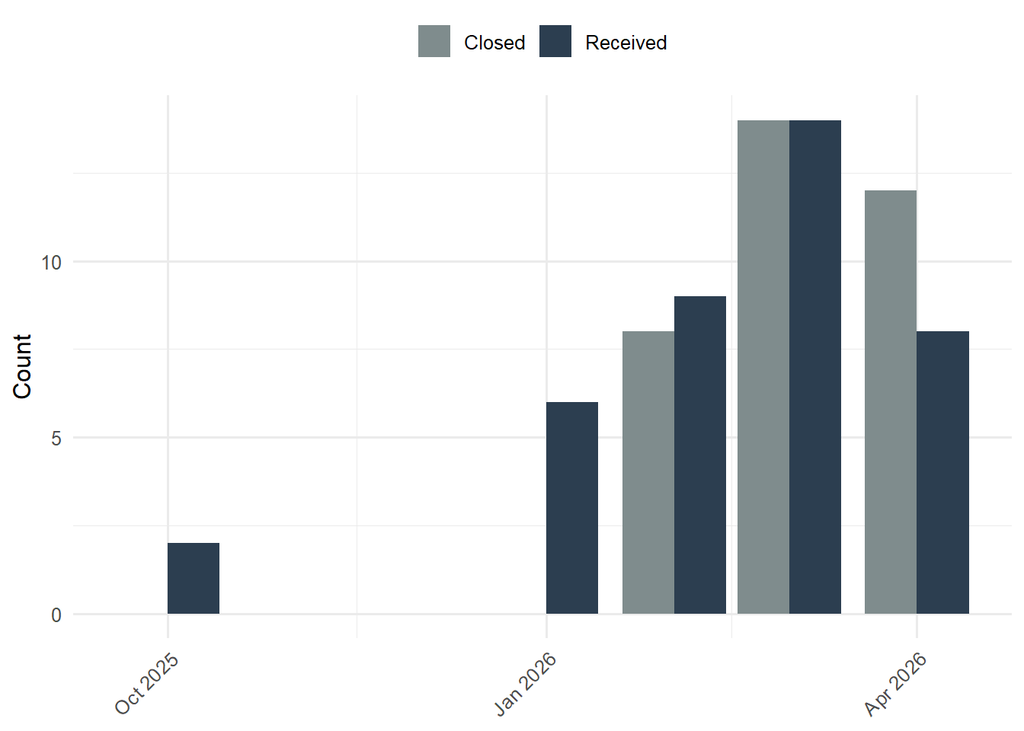

**Summary:** Requests in this reporting period were received across 5 months shown in the chart. The highest intake occurred in March 2026 with 14 requests. Closure activity is shown in 3 months, with the highest number of closures in March 2026 at 14.

## Requestor Analysis

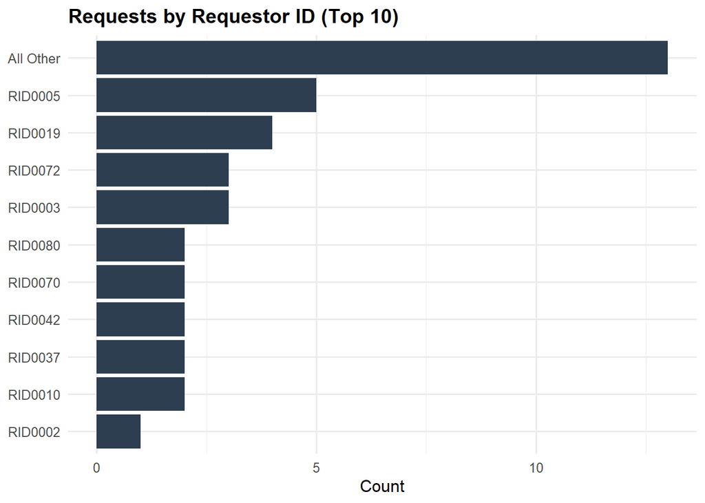

**Summary:** Request activity is distributed across 23 requestor IDs. The highest-volume requestor submitted 5 requests, and 14 requestors have submitted a single request during this reporting period.

## Department Workload

| Department | Open | Closed |
| --- | --- | --- |
| City Manager | 2 | 18 |
| Fire/Code | 1 | 5 |
| Police/Prosecutor | 0 | 6 |
| PZA | 1 | 4 |
| Finance | 1 | 0 |
| P&R | 0 | 1 |

**Summary:** Requests are distributed across 6 departments. The department with the highest number of requests is City Manager with 20 total requests logged during this reporting period.

## Request Scope & Effort

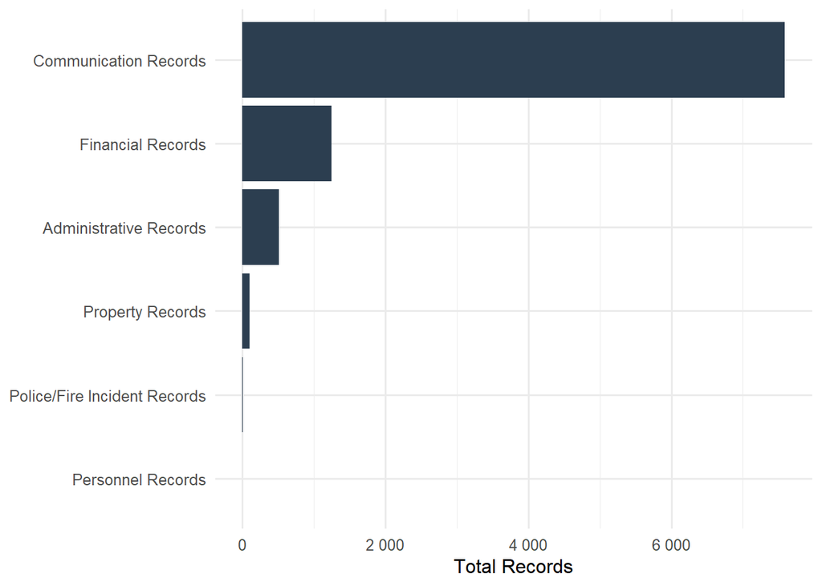

| Metric | Value |
| --- | --- |
| Total Records Requested | 9451 |
| Median Records per Request | 9 |
| Total Hours Worked to Date | 33.6 |
| Median Hours Worked per Request | 1.1 |
| Total Fees Assessed | $7,291.50 |
| Total Fees Collected | $42 |

**Summary:** Based on the fields currently tracked, this report includes measures of request volume, staff time, records produced, and fees. A total of 9451 records have been logged across the requests in this reporting period, with a median of 9 records per request. The request topic generating the greatest number of records is Communication Records, with 7588 records produced. Staff have recorded 33.6 hours worked to date, with a median of 1.1 hours per request. Total fees assessed to date are $7,291.50, and total fees collected to date are $42.

## Aging of Open Requests

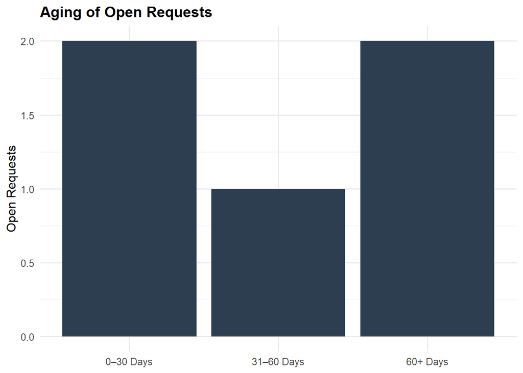

| Metric | Value |
| --- | --- |
| % of Open Requests Over 30 Days | 60% |
| % of Open Requests Over 60 Days | 40% |

## Closure Performance (YTD)

| Metric | Value |
| --- | --- |
| Average Days to Close (YTD) | 17.5 |
| Median Days to Close (YTD) | 10 |
| % Closed Within 30 Days (YTD) | 90.9% |

**Summary:** Year-to-date, the average time to close requests is 17.5 days, and the median time to close is 10 days. 90.9% of closed requests were completed within 30 days.

## Public Log

| Service Request ID | Date Requested | Requestor ID | Request Description | Total Records | Fees Assessed | Fees Collected | Current Status | Days Open | Days to Close |
| --- | --- | --- | --- | --- | --- | --- | --- | --- | --- |
| 109-26 | 2026-04-17 | RID0080 | Incident reports for Fire and Code responding to property | NA | NA | NA | Closed | NA | 3 |
| 113-26 | 2026-04-17 | RID0037 | Any agreements the city has had with Choose Franklin Non-Profit since 2020 to current | 1 | $1.00 | NA | Closed | NA | 6 |
| 114-26 | 2026-04-17 | RID0080 | Records regarding 91 Munroe St | NA | NA | NA | Open | 6 | NA |
| 100-26 | 2026-04-10 | RID0075 | Role, responsibilities, and training of police-prosecutors | NA | NA | NA | Closed | NA | 7 |
| 96-26 | 2026-04-07 | RID0073 | Emails to City Manager or City Council in regards to requests to have such emails read at the April 6, 2026 City Council Meeting. | NA | $2.50 | $0 | Closed | NA | 7 |
| 93-26 | 2026-04-04 | RID0072 | Property/Code records | NA | NA | NA | Closed | NA | 19 |
| 94-26 | 2026-04-04 | RID0072 | Property/Code records | NA | NA | NA | Closed | NA | 19 |
| 95-26 | 2026-04-04 | RID0072 | Property/Code records | NA | NA | NA | Closed | NA | 19 |
| 88-26 | 2026-03-31 | RID0068 | Property/Code records | NA | NA | NA | Open | 23 | NA |
| 90-26 | 2026-03-28 | RID0070 | Incident report | NA | $0.00 | $0 | Closed | NA | 6 |
| 86-26 | 2026-03-24 | RID0067 | Communications Ken Merrifield, NHDOL and City of Franklin | NA | $0.00 | $0 | Closed | NA | 10 |
| 83-26 | 2026-03-23 | RID0003 | All email communications sent and received by the mayor related to their elected position between Jan 1, 2026 and Jan 31, 2026, including but not limited to emails with constituents. This request is i… | NA | $10.00 | $0 | Closed | NA | 24 |
| 84-26 | 2026-03-23 | RID0003 | Most recent performance evaluation(s) for the current city/town manager | 0 | $0.00 | $0 | Closed | NA | NA |
| 75-26 | 2026-03-17 | RID0019 | Facility use form and all related documents for the NOR’EASTER WHITEWATER SYMPOSIUM | 0 | $0.00 | $0 | Closed | NA | 9 |
| 91-26 | 2026-03-17 | RID0070 | Incident report | NA | $0.00 | $0 | Closed | NA | 17 |
| 74-26 | 2026-03-15 | RID0019 | Communications between City and TIF Advisory Board | 101 | $10.00 | $0 | Closed | NA | 18 |
| 70-26 | 2026-03-13 | RID0005 | Copies of all 91A Invoices for last 12 months | 8 | $10.00 | $0 | Closed | NA | 4 |
| 58-26 | 2026-03-05 | RID0047 | Procurement-related records issued by the City of Franklin between February 1, 2024 and February 1, 2026. | 24 | $10.00 | $0 | Closed | NA | 22 |
| 56-26 | 2026-03-04 | RID0045 | Procurement-related records issued by the City of Franklin between January 1, 2023 and December 1, 2025. | 24 | $10.00 | $0 | Closed | NA | 23 |
| 52-26 | 2026-03-03 | RID0042 | Request for Dash Cam and Body-Worn Camera Footage, Tampa, FL case | 0 | $0.00 | $0 | Closed | NA | 0 |
| 53-26 | 2026-03-03 | RID0042 | Request for Dash Cam and Body-Worn Camera Footage, Hooksett, NH case | 0 | $0.00 | $0 | Closed | NA | 0 |
| 54-26 | 2026-03-02 | RID0043 | Request for information about 174 N Main and dam | 53 | $0.00 | $10 | Closed | NA | 3 |
| 45-26 | 2026-02-25 | RID0022 | All purchases made by city Jan 1 2025-current | 855 | $10.00 | $0 | Open | 57 | NA |
| 35-26 | 2026-02-20 | RID0002 | Property/Code records | 0 | $0.00 | $0 | Closed | NA | 13 |
| 38-26 | 2026-02-20 | RID0005 | Records relating to City Manager oversight of City Council compliance with conflict-of-interest and ethics provisions | 9 | $0.00 | $0 | Closed | NA | 13 |
| 55-26 | 2026-02-20 | RID0044 | Incident Report & Dispatch Call Log | 1 | $0.00 | $0 | Closed | NA | 10 |
| 34-26 | 2026-02-17 | RID0006 | 1980-1990 employment records | 0 | $0.00 | $0 | Closed | NA | 6 |
| 32-26 | 2026-02-12 | RID0010 | looking for Fire Dept policies | 364 | $0.00 | $0 | Closed | NA | 7 |
| 49-26 | 2026-02-06 | RID0039 | Salaries, contracts, job descriptions for Councilors and City Manager for last 10 years | 4 | $0.00 | $0 | Closed | NA | 27 |
| 17-26 | 2026-02-02 | RID0019 | city emergency response plan | 122 | $0.00 | $0 | Closed | NA | 2 |
| 19-26 | 2026-02-02 | RID0019 | Odell park lazy river and/or tubing communications | 19 | $0.00 | $0 | Closed | NA | 2 |
| 20-26 | 2026-01-30 | RID0017 | inspections and permit applications for 174 & 175 N Main St | 45 | $0.00 | $12 | Closed | NA | 19 |
| 22-26 | 2026-01-30 | RID0005 | Disclosure of records held by CM of the financial interests of City Council members and Code of Conduct enforcement | 9 | $0.00 | $0 | Closed | NA | 34 |
| 12-26 | 2026-01-27 | RID0018 | 6-21-2023 MV accident reports | 4 | $0.00 | $0 | Closed | NA | 6 |
| 21-26 | 2026-01-20 | RID0005 | City Manager communications since date of hire. | 7468 | $7,218.00 | $0 | Open | 93 | NA |
| 46-26 | 2026-01-20 | RID0005 | Grant information for work performed by Coleman | 52 | $10.00 | $10 | Closed | NA | 66 |
| 48-26 | 2026-01-14 | RID0003 | PD Settlement Agreements and PD Chief Eval | NA | $0.00 | $0 | Closed | NA | 27 |
| 44-26 | 2025-10-23 | RID0010 | Journal entry reports and MS 60-A | NA | $0.00 | $0 | Open | 182 | NA |
| 42-26 | 2025-10-22 | RID0037 | Grant applications, awards and denials for Mill City Park and Franklin Opera House that the City has submitted to any grant agencies from 2018 to current. | 288 | $0.00 | $10 | Closed | NA | 128 |

## About This Report

This report summarizes Right-to-Know (NH RSA 91-A) request activity for the City of Franklin using data from the City’s internal service request tracking log.

The report is generated directly from the underlying request log and reflects the information currently recorded for each request, including request volume, processing timelines, department workload, request topics, records produced, staff time, and associated fees.

This is a **living report** that will be updated periodically as requests are received, processed, and closed. As the City continues to refine its tracking practices, additional metrics or improvements may be incorporated in future versions of the report.